# HW9_Longitudinal_Data_Analysis_Cody_York

Libraries and Data Import

```r
library(nlme)
library(ggplot2)
library(tidyverse)
library(lcsm)
setwd("C:\\Users\\cy_su\\DataspellProjects\\DSCI_610_Data_Analytics_for_Health_Sciences\\Week_14")

teen_alcohol <- read.csv("teen_alcohol.txt", header = TRUE)
head(teen_alcohol)
```

|  | id | age | coa | male | age_14 | alcuse | peer | cpeer | ccoa |
| --- | --- | --- | --- | --- | --- | --- | --- | --- | --- |
| 1 | 1 | 14 | 1 | 0 | 0 | 1.732051 | 1.2649111 | 0.2469111 | 0.549 |
| 2 | 1 | 15 | 1 | 0 | 1 | 2.000000 | 1.2649111 | 0.2469111 | 0.549 |
| 3 | 1 | 16 | 1 | 0 | 2 | 2.000000 | 1.2649111 | 0.2469111 | 0.549 |
| 4 | 2 | 14 | 1 | 1 | 0 | 0.000000 | 0.8944272 | -0.1235728 | 0.549 |
| 5 | 2 | 15 | 1 | 1 | 1 | 0.000000 | 0.8944272 | -0.1235728 | 0.549 |
| 6 | 2 | 16 | 1 | 1 | 2 | 1.000000 | 0.8944272 | -0.1235728 | 0.549 |

Remove unnecessary column and create a new column needed for the model. Also take a summary of the dataset:

```r
teen_alcohol <- subset(teen_alcohol, select = -ccoa)

teen_alcohol$age_14_squared <- teen_alcohol$age_14^2

summary(teen_alcohol)
```

```
       id            age          coa              male            age_14
 Min.   : 1.0   Min.   :14   Min.   :0.0000   Min.   :0.0000   Min.   :0
 1st Qu.:21.0   1st Qu.:14   1st Qu.:0.0000   1st Qu.:0.0000   1st Qu.:0
 Median :41.5   Median :15   Median :0.0000   Median :1.0000   Median :1
 Mean   :41.5   Mean   :15   Mean   :0.4512   Mean   :0.5122   Mean   :1
 3rd Qu.:62.0   3rd Qu.:16   3rd Qu.:1.0000   3rd Qu.:1.0000   3rd Qu.:2
 Max.   :82.0   Max.   :16   Max.   :1.0000   Max.   :1.0000   Max.   :2
     alcuse           peer            cpeer            age_14_squared
 Min.   :0.000   Min.   :0.0000   Min.   :-1.0180000   Min.   :0.000
 1st Qu.:0.000   1st Qu.:0.0000   1st Qu.:-1.0180000   1st Qu.:0.000
 Median :1.000   Median :0.8944   Median :-0.1235728   Median :1.000
 Mean   :0.922   Mean   :1.0176   Mean   :-0.0004405   Mean   :1.667
 3rd Qu.:1.732   3rd Qu.:1.5492   3rd Qu.: 0.5311934   3rd Qu.:4.000
 Max.   :3.606   Max.   :2.5298   Max.   : 1.5118221   Max.   :4.000
```

# Summarise the data for age:

```r
summary(factor(teen_alcohol$age))
```

```
14 15 16
82 82 82
```

# Next we will create a summary of child of alcoholic with each age level:

```r
table(factor(teen_alcohol$coa), factor(teen_alcohol$age))
```

```
    14 15 16
  0 45 45 45
  1 37 37 37
```

# Descriptive stats for alcohol use among the teens in the data:

```r
summary(teen_alcohol$alcuse)
```

```
   Min. 1st Qu.  Median    Mean 3rd Qu.    Max.
  0.000   0.000   1.000   0.922   1.732   3.606
```

```r
tapply(teen_alcohol$alcuse, factor(teen_alcohol$age), summary, na.rm = TRUE)
```

```
$`14`
   Min. 1st Qu.  Median    Mean 3rd Qu.    Max.
 0.0000  0.0000  0.0000  0.6305  1.0000  3.3166

$`15`
   Min. 1st Qu.  Median    Mean 3rd Qu.    Max.
 0.0000  0.0000  1.0000  0.9636  1.6526  3.6056

$`16`
   Min. 1st Qu.  Median    Mean 3rd Qu.    Max.
  0.000   0.000   1.000   1.172   2.000   3.464
```

# Plot a summary of the data. This box plot is looking at alcohol use by age and child of an alcoholic:

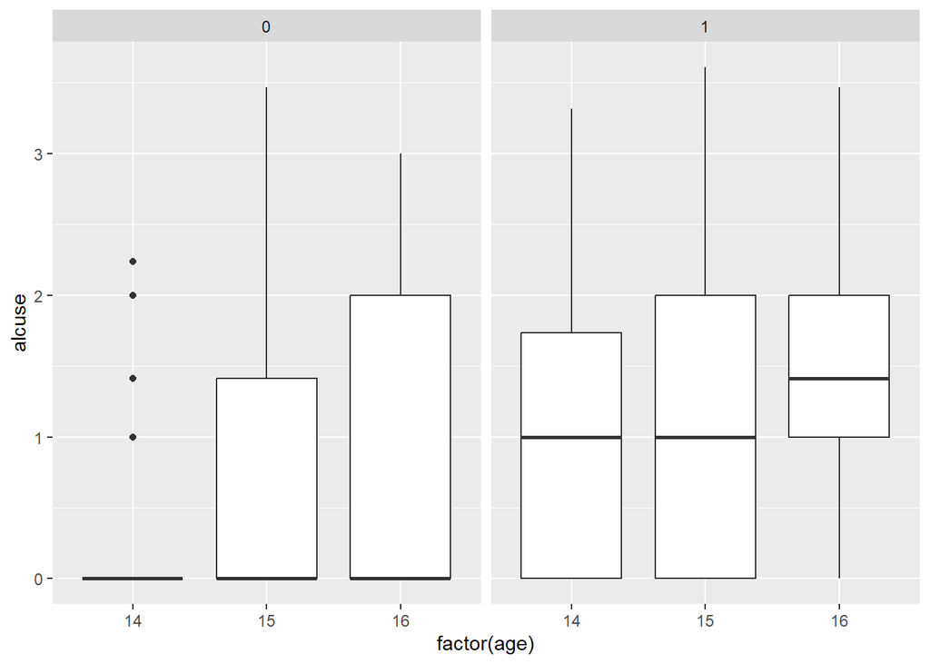

```r
ggplot(data=teen_alcohol, mapping = aes(x =factor(age), y = alcuse))+
  geom_boxplot()+
  facet_wrap(~factor(coa), nrow=1)
```

# Mean Alcohol Use by Child of Alcoholic and Age:

[output not shown]

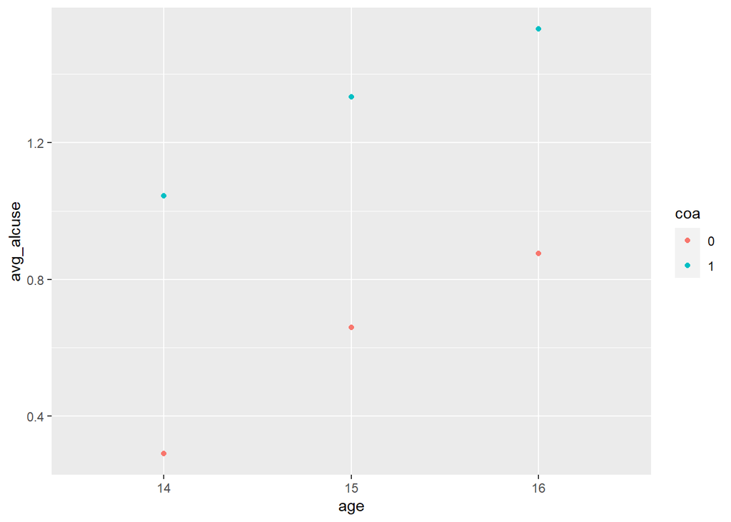

```r
teen_alcohol %>%
  mutate(coa= factor(coa)) %>%
  mutate(age= factor(age)) %>%
  group_by(coa, age) %>%
  summarize(avg_alcuse = mean(alcuse)) %>%
  ggplot()+
  geom_point(aes(y = avg_alcuse, x = age, col = coa))
```

We can see that alcohol use increases by age and if they were a child of an alcoholic.

# Individual Teen Trajectory of Alcohol Use by Age

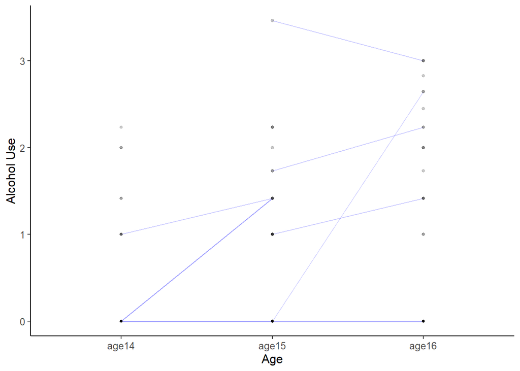

```r
teen_alcohol_1 <- filter(teen_alcohol, coa == 0)
teen_alcohol_2 <- filter(teen_alcohol, coa == 1)
df_W1 <- teen_alcohol_1 %>% pivot_wider(names_from = age, values_from = alcuse)
colnames(df_W1) <- c("id", "coa", "male?", "age_14", "peer", "cpeer", "ccoa", "age14", "age15", "age16")

df_tr<- select(df_W1, id, age14, age15, age16)
x_var_list <- c("age14", "age15", "age16")
plot_trajectories(data = df_tr,
                  id_var = "id",
                  var_list = x_var_list,
                  xlab = "Age", ylab = "Alcohol Use",
                  connect_missing = FALSE,
                  title_n = "Not a Child of An Alcoholic")
```

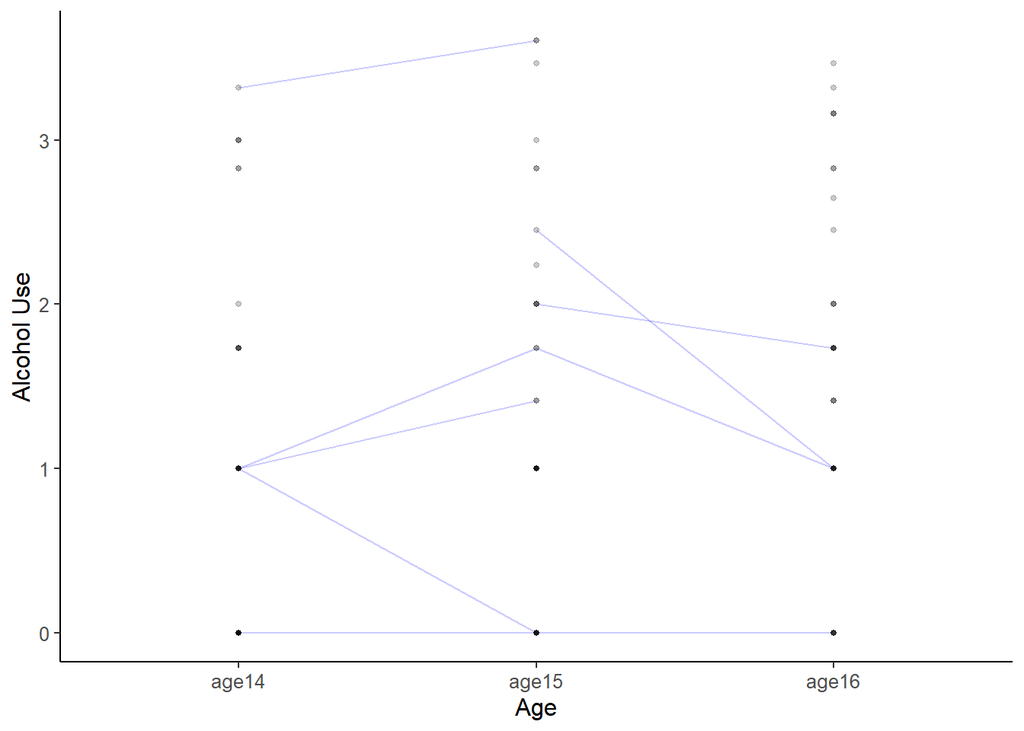

```r
df_W2 <- teen_alcohol_2 %>% pivot_wider(names_from = age, values_from = alcuse)
colnames(df_W2) <- c("id", "coa", "male?", "age_14", "peer", "cpeer", "ccoa", "age14", "age15", "age16")

df_tr_2 <- select(df_W2, id, age14, age15, age16)
x_var_list_2 <- c("age14", "age15", "age16")
plot_trajectories(data = df_tr_2,
                  id_var = "id",
                  var_list = x_var_list_2,
                  xlab = "Age", ylab = "Alcohol Use",
                  connect_missing = FALSE,
                  title_n = "A Child of An Alcoholic")
```

# Create Factors for COA

```r
teen_alcohol$coaF[teen_alcohol$coa == 0]<- 0
teen_alcohol$coaF[teen_alcohol$coa == 1]<- 1
teen_alcohol$coaF <- factor(teen_alcohol$coaF)

teen_alcohol_factored <- teen_alcohol[complete.cases(teen_alcohol), ]
```

# Fit a Random Coefficient Model:

```r
M.1_fit <- lme(alcuse ~ age_14 + age_14_squared + coa + male + cpeer + age_14:coaF + age_14_squared:coaF, random = ~ age_14+age_14_squared | id, data = teen_alcohol)

summary(M.1_fit)
```

```
Linear mixed-effects model fit by REML
  Data: teen_alcohol
       AIC      BIC    logLik
  637.5516 689.6357 -303.7758

Random effects:
 Formula: ~age_14 + age_14_squared | id
 Structure: General positive-definite, Log-Cholesky parametrization
               StdDev    Corr
(Intercept)    0.5255263 (Intr) age_14
age_14         0.6502832  0.291
age_14_squared 0.3357082 -0.418 -0.779
Residual       0.5174448

Fixed effects:  alcuse ~ age_14 + age_14_squared + coa + male + cpeer + age_14:coaF +      age_14_squared:coaF
                          Value Std.Error  DF   t-value p-value
(Intercept)           0.2592713 0.1307988 160  1.982215  0.0492
age_14                0.4467328 0.2192531 160  2.037521  0.0432
age_14_squared       -0.0768888 0.1069084 160 -0.719203  0.4731
coa                   0.5981972 0.1659301  78  3.605115  0.0005
male                  0.1982598 0.1484825  78  1.335240  0.1857
cpeer                 0.6153555 0.1036151  78  5.938860  0.0000
age_14:coaF1         -0.1131547 0.3264013 160 -0.346674  0.7293
age_14_squared:coaF1  0.0318624 0.1591542 160  0.200198  0.8416
 Correlation:
                     (Intr) age_14 ag_14_ coa    male   cpeer  a_14:F
age_14               -0.234
age_14_squared        0.096 -0.923
coa                  -0.526  0.185 -0.075
male                 -0.535  0.000  0.000 -0.080
cpeer                -0.043  0.000  0.000 -0.158  0.231
age_14:coaF1          0.157 -0.672  0.620 -0.275  0.000  0.000
age_14_squared:coaF1 -0.064  0.620 -0.672  0.112  0.000  0.000 -0.923

Standardized Within-Group Residuals:
       Min         Q1        Med         Q3        Max
-2.4654141 -0.3442167 -0.1273617  0.3640934  2.7655606

Number of Observations: 246
Number of Groups: 82
```

```r
M.1_No_SQ_Fit <- lme(alcuse ~ age_14 + age_14_squared + coa + male + cpeer + age_14:coaF + age_14_squared:coaF, random = ~ age_14 | id, data = teen_alcohol)

summary(M.1_No_SQ_Fit)
```

```
Linear mixed-effects model fit by REML
  Data: teen_alcohol
       AIC      BIC    logLik
  635.1253 676.7925 -305.5626

Random effects:
 Formula: ~age_14 | id
 Structure: General positive-definite, Log-Cholesky parametrization
            StdDev    Corr
(Intercept) 0.5199342 (Intr)
age_14      0.3946943 -0.122
Residual    0.5855615

Fixed effects:  alcuse ~ age_14 + age_14_squared + coa + male + cpeer + age_14:coaF +      age_14_squared:coaF
                          Value Std.Error  DF   t-value p-value
(Intercept)           0.2782972 0.1370599 160  2.030479  0.0440
age_14                0.4467328 0.2301940 160  1.940679  0.0541
age_14_squared       -0.0768888 0.1069084 160 -0.719203  0.4731
coa                   0.5964409 0.1759702  78  3.389442  0.0011
male                  0.1626742 0.1505002  78  1.080891  0.2831
cpeer                 0.6305680 0.1050231  78  6.004088  0.0000
age_14:coaF1         -0.1131547 0.3426890 160 -0.330197  0.7417
age_14_squared:coaF1  0.0318624 0.1591541 160  0.200198  0.8416
 Correlation:
                     (Intr) age_14 ag_14_ coa    male   cpeer  a_14:F
age_14               -0.380
age_14_squared        0.260 -0.929
coa                  -0.536  0.296 -0.203
male                 -0.518  0.000  0.000 -0.077
cpeer                -0.042  0.000  0.000 -0.151  0.231
age_14:coaF1          0.255 -0.672  0.624 -0.440  0.000  0.000
age_14_squared:coaF1 -0.175  0.624 -0.672  0.301  0.000  0.000 -0.929

Standardized Within-Group Residuals:
        Min          Q1         Med          Q3         Max
-2.60743164 -0.37793427 -0.09636385  0.40885363  2.37771230

Number of Observations: 246
Number of Groups: 82
```

# Perform a test to determine which model to move forward with

```r
anova(M.1_fit, M.1_No_SQ_Fit)
```

|  | call | Model | df | AIC | BIC | logLik | Test | L.Ratio | p-value |
| --- | --- | --- | --- | --- | --- | --- | --- | --- | --- |
| M.1_fit | lme.formula(fixed = alcuse ~ age_14 + age_14_squared + coa + male + cpeer + age_14:coaF + age_14_squared:coaF, data = teen_alcohol, random = ~age_14 + age_14_squared \| id) | 1 | 15 | 637.5516 | 689.6357 | -303.7758 |  | NA | NA |
| M.1_No_SQ_Fit | lme.formula(fixed = alcuse ~ age_14 + age_14_squared + coa + male + cpeer + age_14:coaF + age_14_squared:coaF, data = teen_alcohol, random = ~age_14 \| id) | 2 | 12 | 635.1253 | 676.7925 | -305.5626 | 1 vs 2 | 3.573655 | 0.3113342 |

Since the pvalue is above 0 we will remove the Quadratic Equation.

# Test on the Fixed Effects

```r
M.2_Fit  <- lme(alcuse ~ age_14 + age_14_squared + coa + male + cpeer + age_14:coaF + age_14_squared:coaF, random = ~ age_14 | id, method = "ML", data = teen_alcohol)

M.3_Fit  <- lme(alcuse ~ age_14 + age_14_squared + coa + male + cpeer + age_14:coaF, random = ~ age_14 | id,  method = "ML", data = teen_alcohol)

anova(M.3_Fit, M.2_Fit)
```

|  | call | Model | df | AIC | BIC | logLik | Test | L.Ratio | p-value |
| --- | --- | --- | --- | --- | --- | --- | --- | --- | --- |
| M.3_Fit | lme.formula(fixed = alcuse ~ age_14 + age_14_squared + coa + male + cpeer + age_14:coaF, data = teen_alcohol, random = ~age_14 \| id, method = "ML") | 1 | 11 | 611.9025 | 650.4612 | -294.9513 |  | NA | NA |
| M.2_Fit | lme.formula(fixed = alcuse ~ age_14 + age_14_squared + coa + male + cpeer + age_14:coaF + age_14_squared:coaF, data = teen_alcohol, random = ~age_14 \| id, method = "ML") | 2 | 12 | 613.8615 | 655.9254 | -294.9307 | 1 vs 2 | 0.04107104 | 0.8394009 |

We will drop the interaction with the quadratic equation

```r
M.4_Fit  <- lme(alcuse ~ age_14 + age_14_squared + coa + male + cpeer, random = ~ age_14 | id,  method = "ML", data = teen_alcohol)

anova(M.4_Fit, M.3_Fit)
```

|  | call | Model | df | AIC | BIC | logLik | Test | L.Ratio | p-value |
| --- | --- | --- | --- | --- | --- | --- | --- | --- | --- |
| M.4_Fit | lme.formula(fixed = alcuse ~ age_14 + age_14_squared + coa + male + cpeer, data = teen_alcohol, random = ~age_14 \| id, method = "ML") | 1 | 10 | 610.0578 | 645.1111 | -295.0289 |  | NA | NA |
| M.3_Fit | lme.formula(fixed = alcuse ~ age_14 + age_14_squared + coa + male + cpeer + age_14:coaF, data = teen_alcohol, random = ~age_14 \| id, method = "ML") | 2 | 11 | 611.9025 | 650.4612 | -294.9513 | 1 vs 2 | 0.1552555 | 0.6935628 |

We will also omit the interaction with the linear interaction.

```r
M.5_Fit  <- lme(alcuse ~ age_14 + age_14_squared + coa + male, random = ~ age_14 | id,  method = "ML", data = teen_alcohol)

anova(M.5_Fit, M.4_Fit)
```

|  | call | Model | df | AIC | BIC | logLik | Test | L.Ratio | p-value |
| --- | --- | --- | --- | --- | --- | --- | --- | --- | --- |
| M.5_Fit | lme.formula(fixed = alcuse ~ age_14 + age_14_squared + coa + male, data = teen_alcohol, random = ~age_14 \| id, method = "ML") | 1 | 9 | 638.7167 | 670.2647 | -310.3584 |  | NA | NA |
| M.4_Fit | lme.formula(fixed = alcuse ~ age_14 + age_14_squared + coa + male + cpeer, data = teen_alcohol, random = ~age_14 \| id, method = "ML") | 2 | 10 | 610.0578 | 645.1111 | -295.0289 | 1 vs 2 | 30.65892 | 3.076096e-08 |

We will not omit the cpeer form the model.

```r
M.6_Fit  <- lme(alcuse ~ age_14 + age_14_squared + coa + cpeer, random = ~ age_14 | id,  method = "ML", data = teen_alcohol)

anova(M.6_Fit, M.4_Fit)
```

|  | call | Model | df | AIC | BIC | logLik | Test | L.Ratio | p-value |
| --- | --- | --- | --- | --- | --- | --- | --- | --- | --- |
| M.6_Fit | lme.formula(fixed = alcuse ~ age_14 + age_14_squared + coa + cpeer, data = teen_alcohol, random = ~age_14 \| id, method = "ML") | 1 | 9 | 609.2146 | 640.7626 | -295.6073 |  | NA | NA |
| M.4_Fit | lme.formula(fixed = alcuse ~ age_14 + age_14_squared + coa + male + cpeer, data = teen_alcohol, random = ~age_14 \| id, method = "ML") | 2 | 10 | 610.0578 | 645.1111 | -295.0289 | 1 vs 2 | 1.15679 | 0.2821323 |

We can omit the Male? from the model.

```r
M.7_Fit  <- lme(alcuse ~ age_14 + age_14_squared + cpeer, random = ~ age_14 | id,  method = "ML", data = teen_alcohol)

anova(M.7_Fit, M.6_Fit)
```

|  | call | Model | df | AIC | BIC | logLik | Test | L.Ratio | p-value |
| --- | --- | --- | --- | --- | --- | --- | --- | --- | --- |
| M.7_Fit | lme.formula(fixed = alcuse ~ age_14 + age_14_squared + cpeer, data = teen_alcohol, random = ~age_14 \| id, method = "ML") | 1 | 8 | 621.2064 | 649.2490 | -302.6032 |  | NA | NA |
| M.6_Fit | lme.formula(fixed = alcuse ~ age_14 + age_14_squared + coa + cpeer, data = teen_alcohol, random = ~age_14 \| id, method = "ML") | 2 | 9 | 609.2146 | 640.7626 | -295.6073 | 1 vs 2 | 13.99178 | 0.0001836115 |

We cannot omit the coa.

# Final Model Analysis

```r
M.8_Final <- lme(alcuse ~ age_14 + age_14_squared + coa + cpeer, random = ~ age_14 | id,  method = "REML", data = teen_alcohol)
summary(M.8_Final)
```

```
Linear mixed-effects model fit by REML
  Data: teen_alcohol
       AIC      BIC    logLik
  624.3371 655.7003 -303.1686

Random effects:
 Formula: ~age_14 | id
 Structure: General positive-definite, Log-Cholesky parametrization
            StdDev    Corr
(Intercept) 0.5107430 (Intr)
age_14      0.3929222 -0.072
Residual    0.5820816

Fixed effects:  alcuse ~ age_14 + age_14_squared + coa + cpeer
                    Value Std.Error  DF   t-value p-value
(Intercept)     0.3729993 0.1087789 162  3.428968  0.0008
age_14          0.3956752 0.1695299 162  2.333955  0.0208
age_14_squared -0.0625119 0.0787268 162 -0.794036  0.4283
coa             0.5711970 0.1489772  79  3.834123  0.0003
cpeer           0.6092227 0.1022602  79  5.957571  0.0000
 Correlation:
               (Intr) age_14 ag_14_ coa
age_14         -0.346
age_14_squared  0.241 -0.929
coa            -0.618  0.000  0.000
cpeer           0.101  0.000  0.000 -0.162

Standardized Within-Group Residuals:
        Min          Q1         Med          Q3         Max
-2.66515734 -0.37760675 -0.07862853  0.38420626  2.39548918

Number of Observations: 246
Number of Groups: 82
```

```r
anova(M.8_Final)
```

|  | numDF | denDF | F-value | p-value |
| --- | --- | --- | --- | --- |
| (Intercept) | 1 | 162 | 121.0975075 | 0.000000e+00 |
| age_14 | 1 | 162 | 18.5507358 | 2.858494e-05 |
| age_14_squared | 1 | 162 | 0.6304928 | 4.283362e-01 |
| coa | 1 | 79 | 23.6658843 | 5.740630e-06 |
| cpeer | 1 | 79 | 35.4926566 | 6.751502e-08 |

The Intercept βˆ0 = 0.37 represents the estimated mean Alcohol Use Score for the teens aged 14 in the reference of whether they are children of alcoholics. The Parameter βˆ1 = 0.4 this is both positive and significant and this means that age increases the use of alcohol. The Parameter βˆ3 = 0.57 this is both positive and significant and this means that being a child of an alcoholic increases the chance of alcohol use. The Parameter βˆ4 = 0.61 this is both positive and significant and this means that having peers that use alcohol increases the chance of alcohol use.